# Rugby World Cup 2015 Analysis

Michael Khan

4 January 2016

Set working directory. Change this path as needed to run

```r
setwd("~/Dropbox/DataAnalytics/RugbyWC2015/code")
```

Necessary package imports

```r
library(reshape2)
library(cluster)
library(ggplot2)
```

### Importing Data

*data contains the original data provided.* playerPosition contains data on players’ physical attributes and positions

```r
data <- read.csv('../data/rwc2015.csv', header = TRUE)
playerPositions <- read.csv('../data/playerPositions.csv', header = TRUE)
```

### Quick exploration of the data

```r
dim(data)
```

```
## [1] 4088    4
```

```r
names(data)
```

```
## [1] "player_name" "country"     "metric"      "value"
```

From this we can see that there are 4088 observations with 4 variables each: player_name, country, metric, value

Now lets look further into the data

```r
summary(data)
```

```
##               player_name           country
##  Josh Furno         :  10   New Zealand : 234
##  Kieran Read        :  10   Argentina   : 226
##  Agustín Creevy     :   9   France      : 222
##  Ben McCalman       :   9   Wales       : 221
##  Bismarck Du Plessis:   9   South Africa: 216
##  Bradley Davies     :   9   Ireland     : 214
##  (Other)            :4032   (Other)     :2755
##                     metric        value
##  matches               :622   Min.   :  0.0
##  tries                 :622   1st Qu.:  1.0
##  carries               :600   Median :  3.0
##  metres_made           :583   Mean   : 13.7
##  carries_over_gain_line:566   3rd Qu.: 11.0
##  turnovers_won         :343   Max.   :400.0
##  (Other)               :752
```

From this summary of the fields we can start to see how the data is organised in the file. It looks like each player is represented by multiple rows of data, with the metric field showing which of the metrics is being show in this row.

```r
unique(data$metric)
```

```
##  [1] carries                clean_breaks           metres_made
##  [4] offloads_made          turnovers_won          matches
##  [7] tries                  carries_over_gain_line lineout_steals
## [10] lineouts_won
## 10 Levels: carries carries_over_gain_line clean_breaks ... turnovers_won
```

As we can see from the above command there are 10 different metrics shown in this data.

### Data Munging

As I continue with my analysis I would prefer to transform this data so that each metric is a variable and each row is a player. For this task I will use the [reshape2](https://cran.r-project.org/web/packages/reshape2/index.html) package imported above

```r
new_data <- dcast(data, player_name + country ~ metric)
new_data_NAs <- new_data
```

Here is an short extract of what the data look like now

```r
head(new_data)
```

```
##          player_name      country carries carries_over_gain_line
## 1    Aaron Carpenter       Canada      37                     20
## 2       Aaron Jarvis        Wales       8                      2
## 3        Aaron Smith  New Zealand      22                     11
## 4 Adam Ashley-Cooper    Australia      21                      6
## 5    Adriaan Strauss South Africa      25                     15
## 6     Adrian Apostol      Romania      14                      9
##   clean_breaks lineout_steals lineouts_won matches metres_made
## 1           NA             NA            6       4          77
## 2           NA             NA           NA       3           5
## 3            3             NA           NA       4          65
## 4            4             NA           NA       4         207
## 5            1             NA           18       4          68
## 6            3             NA           NA       3          91
##   offloads_made tries turnovers_won
## 1             1     1            NA
## 2            NA     0            NA
## 3             2     1             1
## 4             1     1             2
## 5            NA     1             2
## 6            NA     2             2
```

As we can see from the above extract NA was inserted where the values did not exist for a given player and metric. It looks like the NAs signify when a player has 0 of a metric, although I am not 100% sure for this exercise I will replace NAs with 0

```r
new_data[is.na(new_data)] <- 0
```

The summary of the 10 different metrics’ is now more true to reality

```r
summary(new_data)
```

```
##              player_name     country       carries
##  Aaron Carpenter   :  1   Fiji   : 33   Min.   : 0.0
##  Aaron Jarvis      :  1   Wales  : 33   1st Qu.: 7.0
##  Aaron Smith       :  1   Canada : 32   Median :14.0
##  Adam Ashley-Cooper:  1   England: 32   Mean   :15.9
##  Adriaan Strauss   :  1   France : 32   3rd Qu.:22.0
##  Adrian Apostol    :  1   Ireland: 32   Max.   :80.0
##  (Other)           :616   (Other):428
##  carries_over_gain_line  clean_breaks   lineout_steals   lineouts_won
##  Min.   : 0.00          Min.   : 0.00   Min.   :0.000   Min.   : 0.00
##  1st Qu.: 2.00          1st Qu.: 0.00   1st Qu.:0.000   1st Qu.: 0.00
##  Median : 5.50          Median : 0.00   Median :0.000   Median : 0.00
##  Mean   : 6.68          Mean   : 1.07   Mean   :0.133   Mean   : 1.53
##  3rd Qu.:10.00          3rd Qu.: 1.00   3rd Qu.:0.000   3rd Qu.: 0.00
##  Max.   :36.00          Max.   :11.00   Max.   :5.000   Max.   :49.00
##
##     matches      metres_made    offloads_made       tries
##  Min.   :1.00   Min.   :  0.0   Min.   : 0.00   Min.   :0.000
##  1st Qu.:2.00   1st Qu.: 12.0   1st Qu.: 0.00   1st Qu.:0.000
##  Median :3.00   Median : 36.0   Median : 1.00   Median :0.000
##  Mean   :3.17   Mean   : 58.7   Mean   : 1.07   Mean   :0.404
##  3rd Qu.:4.00   3rd Qu.: 81.8   3rd Qu.: 2.00   3rd Qu.:1.000
##  Max.   :5.00   Max.   :400.0   Max.   :10.00   Max.   :8.000
##
##  turnovers_won
##  Min.   : 0.00
##  1st Qu.: 0.00
##  Median : 1.00
##  Mean   : 1.07
##  3rd Qu.: 2.00
##  Max.   :10.00
##
```

I’m going to divide all the metrics by the number of games played by each player to remove bias of the number of games each player took part in.

```r
columnsToDivide <- c(3,4,5,6,7,9,10,11,12)
for(i in columnsToDivide) {
  new_data[ ,i] = new_data[ ,i] / new_data$matches
}
```

Finding the leader in each category

```r
max_carries <- new_data[new_data$carries == max(new_data$carries),]
max_cogl <- new_data[new_data$carries_over_gain_line == max(new_data$carries_over_gain_line),]
max_cb <- new_data[new_data$clean_breaks == max(new_data$clean_breaks),]
max_los <- new_data[new_data$lineout_steals == max(new_data$lineout_steals),]
max_low <- new_data[new_data$lineouts_won == max(new_data$lineouts_won),]
max_mm <- new_data[new_data$metres_made == max(new_data$metres_made),]
max_om <- new_data[new_data$offloads_made == max(new_data$offloads_made),]
max_tries <- new_data[new_data$tries == max(new_data$tries),]
max_tow <- new_data[new_data$turnovers_won == max(new_data$turnovers_won),]
```

### Clustering players

> I’m going to try to use K-means clustering to see if we can group players by positions by using just the 10 fields provided in the data. With K-means you have to specify the number of groups to use for clustering I’m going to start with 9, one for each position: prop, hooker, lock, back row, scrum half, fly half, center, wing and full back.

The above quote shows my initial intention of using clustering algorithm, having some knowledge of Rugby I knew that k-means was unlikely to be able to create 9 separate clusters not due to a fault in the algorithm but because of the nature of the sport. Many players can interchange between multiple positions for example a player like Australia’s Kurtley Beale can basically play any position in the back line. As well as players being interchangeable in modern day rugby the role of players in different positions can be very similar for example back-row forwards and centers can end up doing a lot of the same jobs and when looking at their stats it can be difficult to differentiate between position. After a lot of experimentation with the number of clusters I decided that 3 clusters made the most sense, while this didn’t split the players into each individual position it did create a pretty interesting division of the player.

```r
set.seed(1)
kmeansIn <- data.matrix(new_data[, -c(1,2,8)])
kmeansRes <- kmeans(kmeansIn, centers = 3)
```

adding a new column to the data to hold the number of the cluster it was assigned to.

```r
new_data$cluster <- kmeansRes$cluster
```

#### Merging player stats and position data.

To analyse the results of the clustering on player positions I had to find a data source that included player position. I found a [dataset](http://www.rugbyhow.com/2015RWC-all-player-sizes.html#AName%20order) with physical measurements of players for the 2015 Rugby World Cup that also included player position. I merged the 2 data sets using player names

```r
merged <- merge(x = new_data, y = playerPositions, by.x = 'player_name', by.y = 'Player.name')
merged_left <- merge(x = new_data, y = playerPositions, by.x = 'player_name', by.y = 'Player.name', all.x = TRUE)
merged_right <- merge(x = new_data, y = playerPositions, by.x = 'player_name', by.y = 'Player.name', all.y = TRUE)

missing_left <- merged_left[is.na(merged_left$Pos), ]
missing_right <- merged_right[is.na(merged_right$country), ]
```

Lets look at a table of position vs cluster

```r
table(merged$cluster, merged$Pos)
```

```
##
##     back-row centre fly-half fullback hooker Lock prop scrum-half wing
##   1       27     32       19       11      2    2    0          6   30
##   2        2      6        1       13      0    0    0          1   15
##   3       73     28       18        2     43   59   85         40   20
```

### Cluster Plot

The hereunder silhouette plot provides an interesting way at visualizing the effectiveness of the clusters created by k-means in high-dimensional problem such as this one.

Each horizontal bar represents the ratio of how well a player fits into his cluster as apposed to his next nearest cluster. The closer to 1 these bars are the better a player fits into his currency cluster. Interesting observations from this graph include: *Cluster 3 is the largest and the best fit cluster with an average score ( s<sub>i</sub> ) of 0.86* The small spike below 0 in cluster 1 signifies that a small number of players may have been more suitable in an other cluster.

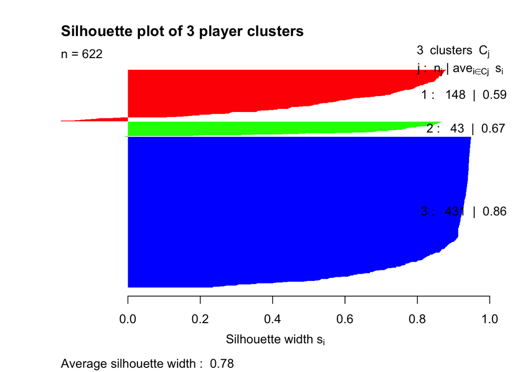

```r
graphColors = c('red', 'green', 'blue')
dE <- daisy(kmeansIn)
dE2 <- dE^2
silPlot <- silhouette(kmeansRes$cl, dE2)
plot(silPlot, col=graphColors, main='Silhouette plot of 3 player clusters')
```

### Exploratory Graphs

##### Comparing tries scored by cluster

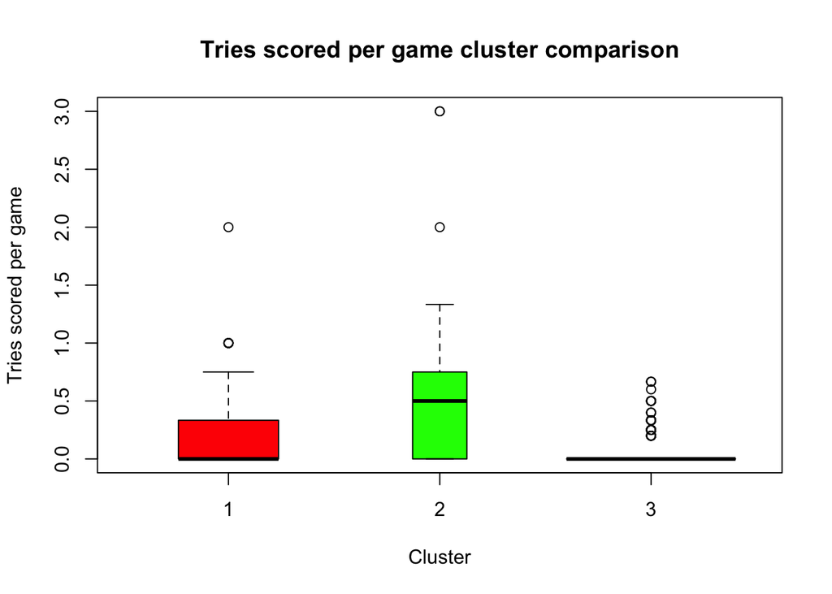

```r
boxplot(merged$tries ~ merged$cluster, varwidth = TRUE, col=graphColors, xlab='Cluster', ylab='Tries scored per game', main='Tries scored per game cluster comparison')
```

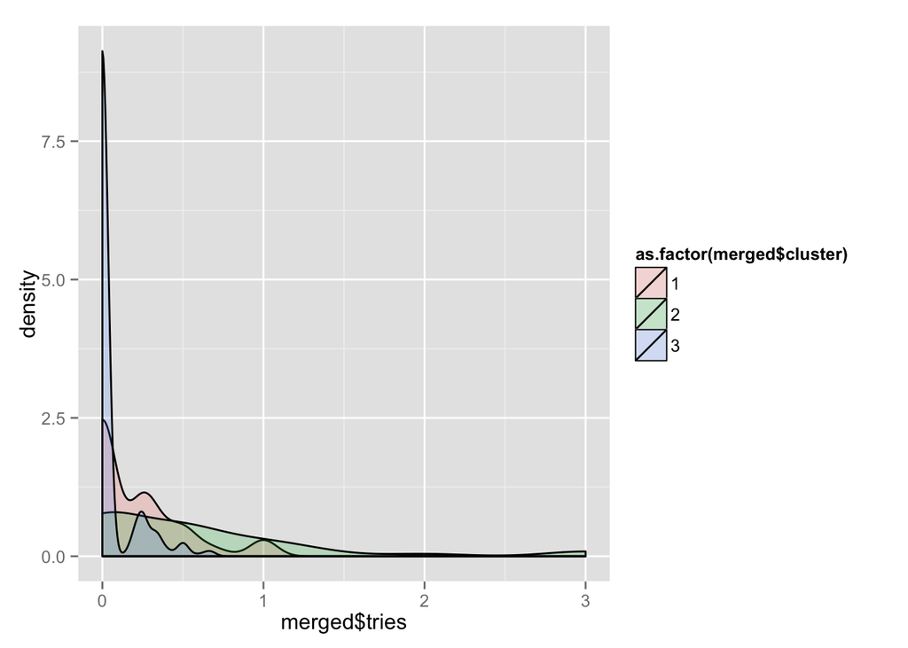

```r
ggplot(merged, aes(merged$tries, fill = as.factor(merged$cluster))) + geom_density(alpha = 0.2)
```

##### Comparing meters made by cluster

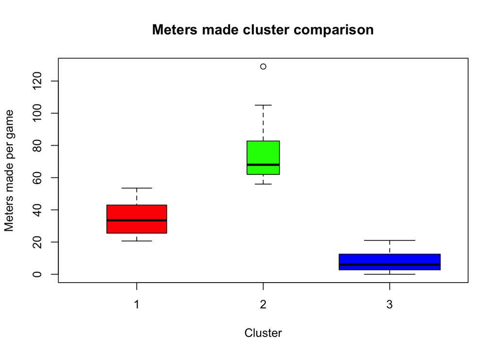

```r
boxplot(merged$metres_made ~ merged$cluster, varwidth = TRUE, col=graphColors, xlab='Cluster', ylab='Meters made per game', main='Meters made cluster comparison')
```

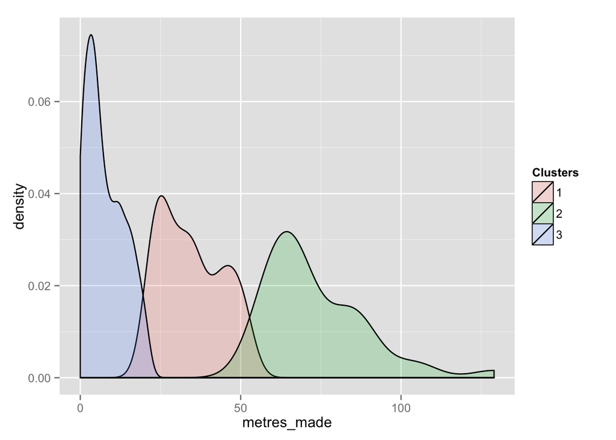

```r
#ggplot(merged, aes(x=as.factor(merged$cluster), y=metres_made, fill=as.factor(merged$cluster))) + geom_boxplot() + scale_fill_discrete(name = 'Clusters')
ggplot(merged, aes(metres_made, fill = as.factor(merged$cluster))) + geom_density(alpha = 0.2) + scale_fill_discrete(name = 'Clusters')
```

##### Comparing turn overs by cluster

[figure not shown]

```r
boxplot(merged$turnovers_won ~ merged$cluster, varwidth = TRUE, col=graphColors, xlab='Cluster', ylab='Meters made per game', main='Meters made cluster comparison')
```

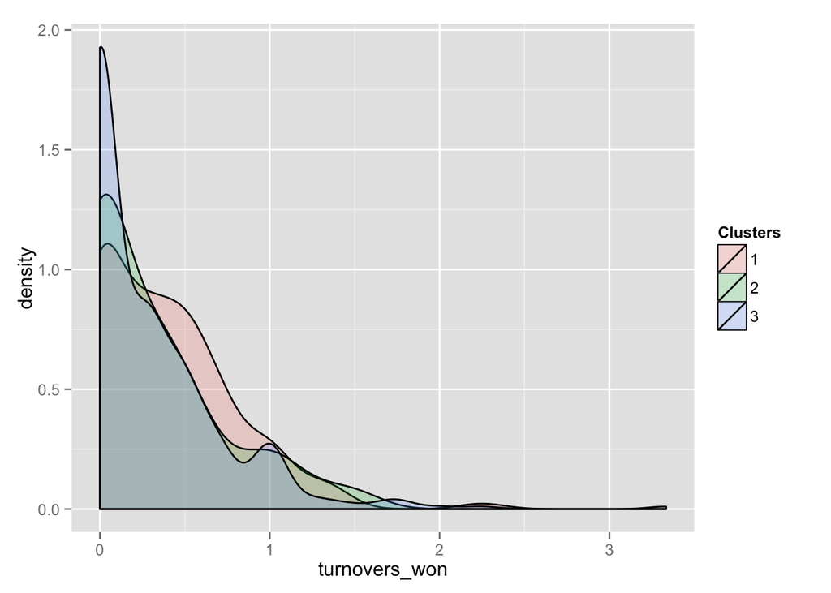

```r
ggplot(merged, aes(turnovers_won, fill = as.factor(merged$cluster))) + geom_density(alpha = 0.2) + scale_fill_discrete(name = 'Clusters')
```

##### Comparing clean breaks by cluster

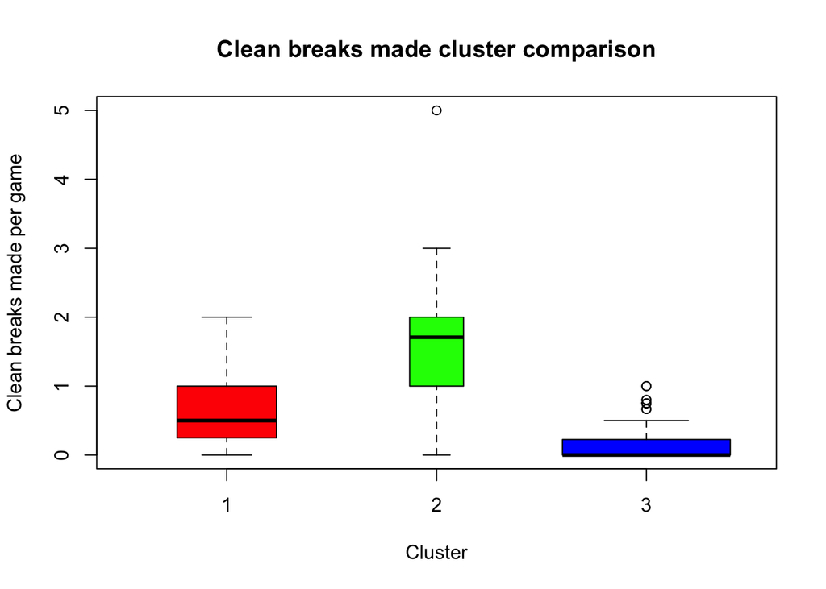

```r
boxplot(merged$clean_breaks ~ merged$cluster, varwidth = TRUE, col=graphColors, xlab='Cluster', ylab='Clean breaks made per game', main='Clean breaks made cluster comparison')
```

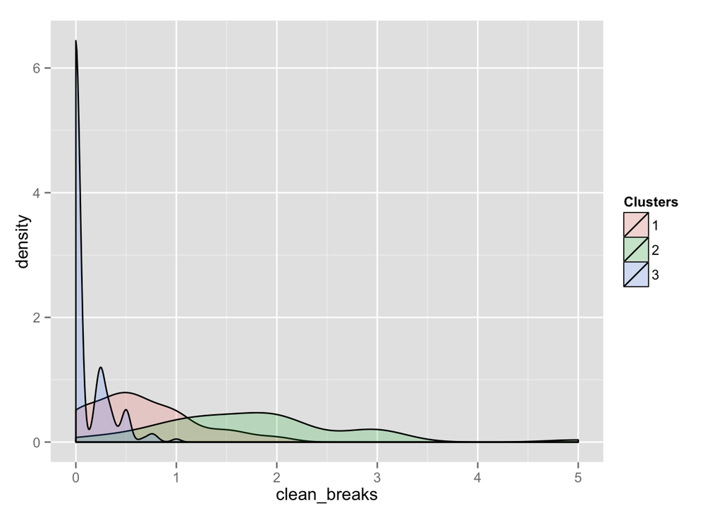

```r
ggplot(merged, aes(clean_breaks, fill = as.factor(merged$cluster))) + geom_density(alpha = 0.2) + scale_fill_discrete(name = 'Clusters')
```

##### Comparing carries over gain line (cogl) by cluster

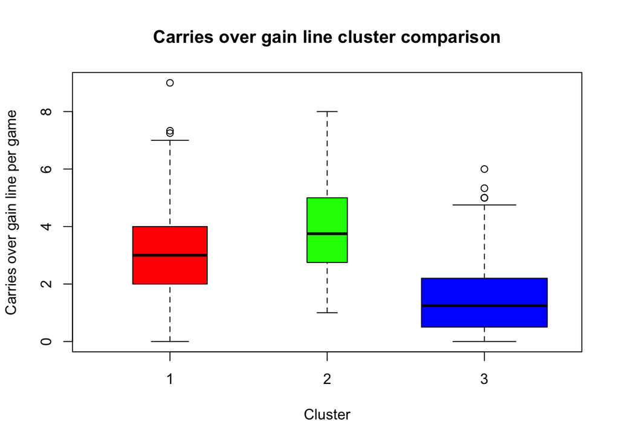

```r
boxplot(merged$carries_over_gain_line ~ merged$cluster, varwidth = TRUE, col=graphColors, xlab='Cluster', ylab='Carries over gain line per game', main='Carries over gain line cluster comparison')
```

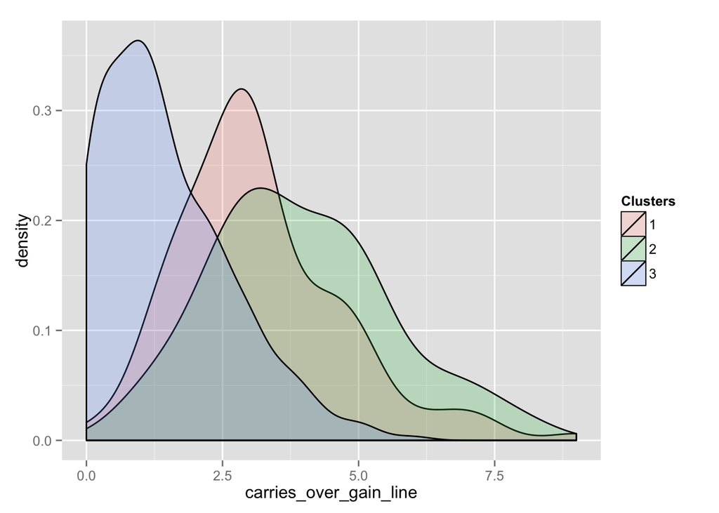

```r
ggplot(merged, aes(carries_over_gain_line, fill = as.factor(merged$cluster))) + geom_density(alpha = 0.2) + scale_fill_discrete(name = 'Clusters')
```